# Comentários e cultura

### Aluno: Victor Emanuel Farias da Costa Borges

```r
dados = read_csv(
    here::here("data/participation-per-country.csv"),
    col_types = cols(
        .default = col_double(),
        site = col_character(),
        country = col_character(),
        geo = col_character(),
        four_regions = col_character(),
        eight_regions = col_character(),
        six_regions = col_character(),
        `World bank income group 2017` = col_character()
    )
) %>%
    filter(usuarios > 200)
glimpse(dados)
```

```
## Observations: 121
## Variables: 21
## $ site                           <chr> "StackOverflow", "StackOverflow", "S...
## $ country                        <chr> "Argentina", "Australia", "Austria",...
## $ PDI                            <dbl> 49, 36, 11, 80, 65, 69, 70, 39, 63, ...
## $ IDV                            <dbl> 46, 90, 55, 20, 75, 38, 30, 80, 23, ...
## $ MAS                            <dbl> 56, 61, 79, 55, 54, 49, 40, 52, 28, ...
## $ UAI                            <dbl> 86, 51, 70, 60, 94, 76, 85, 48, 86, ...
## $ usuarios                       <dbl> 2798, 12313, 2518, 2558, 4275, 10717...
## $ responderam_prop               <dbl> 0.5357398, 0.6133355, 0.6310564, 0.3...
## $ perguntaram_prop               <dbl> 0.5210865, 0.5897832, 0.5933280, 0.4...
## $ editaram_prop                  <dbl> 0.09256612, 0.14699911, 0.14932486, ...
## $ comentaram_prop                <dbl> 0.25339528, 0.33395598, 0.35027800, ...
## $ GNI                            <dbl> NA, 59570, 48160, 840, 44990, 11630,...
## $ Internet                       <dbl> 51.0, 79.5, 79.8, 5.0, 78.0, 45.0, 5...
## $ EPI                            <dbl> 59.02, NA, 63.21, NA, 61.21, 49.96, ...
## $ geo                            <chr> "arg", "aus", "aut", "bgd", "bel", "...
## $ four_regions                   <chr> "americas", "asia", "europe", "asia"...
## $ eight_regions                  <chr> "america_south", "east_asia_pacific"...
## $ six_regions                    <chr> "america", "east_asia_pacific", "eur...
## $ Latitude                       <dbl> -34.00000, -25.00000, 47.33333, 24.0...
## $ Longitude                      <dbl> -64.00000, 135.00000, 13.33333, 90.0...
## $ `World bank income group 2017` <chr> "Upper middle income", "High income"...
```

Estamos interessados na relação entre quanto as pessoas de diferentes países comentam em questões dos outros. A proporção das pessoas do país que comentou nas questões de outros está medido na variável `comentaram_prop`.

Considerando essa variável, queremos examinar a relação entre ela e o quão hierárquicas são as relações em um país (`PDI`). Queremos também levar em conta o quanto as pessoas daquele país têm acesso à Internet (`Internet`) e qual o tamanho da base de dados que detectamos daquele país (`usuarios`).

## Examinando essa relação

### Faça uma visualização que usa os princípios de eficácia no projeto de visualizações para facilitar as comparações que você acha que são as mais importantes para entendermos esse contexto.

Como queremos analisar a relação entre a proporção de pessoas no país que comentou questões dos outros e o quão hierárquicas são elas, incluindo a proporção de pessoas que têm acesso à Internet e o tamanho da base de dados do país, iremos criar uma visualização que dê para enxergar a relação entre as variáveis `comentaram_prop` e `PDI`, nos eixos X e Y respectivamente, com `Internet` e `usuarios` como variáveis auxiliares de legenda, através dos valores de cor e tamanho, respectivamente.

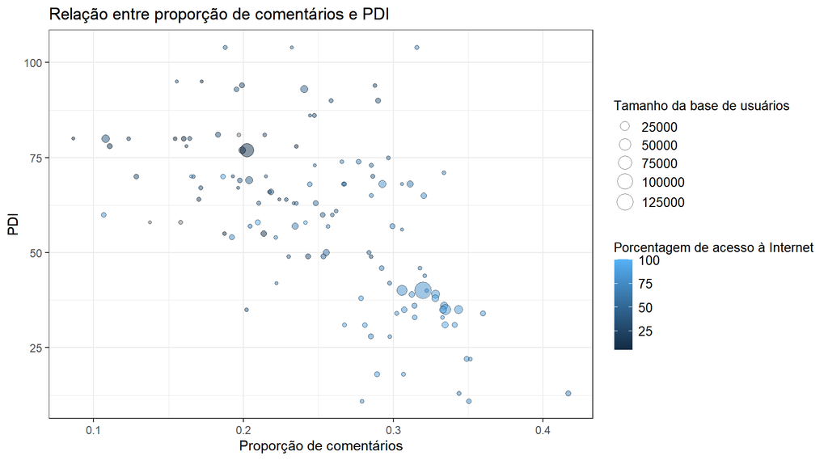

```r
dados %>%
  ggplot(aes(x = comentaram_prop, y = PDI, fill = Internet, size = usuarios)) +
  geom_point(alpha=0.5, shape=21) +
  labs(x = "Proporção de comentários", y = "PDI", size = "Tamanho da base de usuários", fill = "Porcentagem de acesso à Internet", title = "Relação entre proporção de comentários e PDI") +
  theme(legend.position = "right", legend.direction = "vertical", legend.text = element_text(size = 10), legend.key.size = unit(0.5,"cm"), legend.title = element_text(size = 10))
```

## Outras formas de ver

### Em seguida, faça 5 visualizações que usem as mesmas variáveis e também pontos, mas que sejam **menos eficazes** que a que você escolheu acima.

Outros tipos de visualizações podem ser feitos com os mesmos dados, mas serão menos eficazes, como:

1. Gráfico em linhas

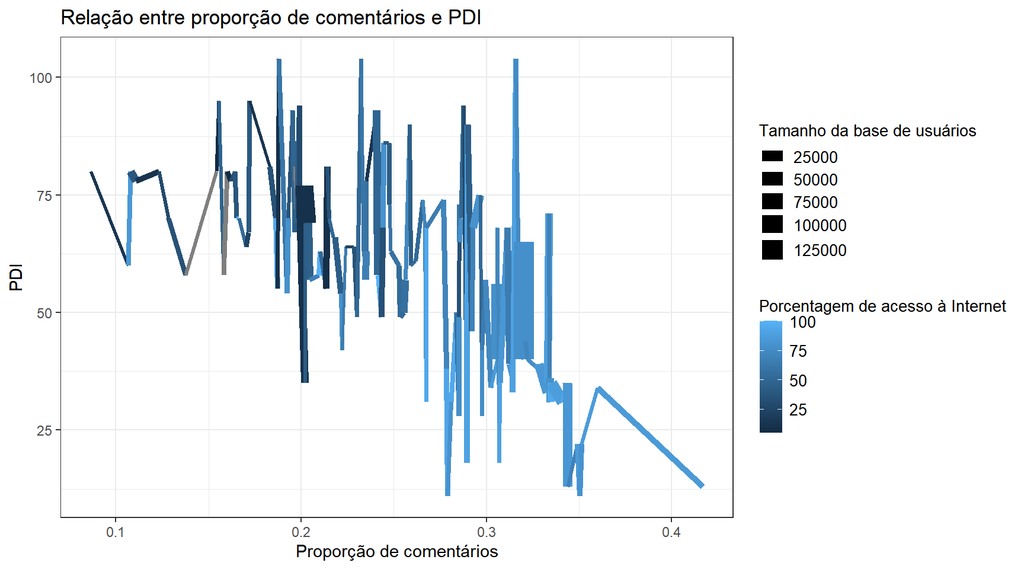

```r
dados %>%
  ggplot(aes(x = comentaram_prop, y = PDI, colour = Internet, size = usuarios)) +
  geom_line() +
  labs(x = "Proporção de comentários", y = "PDI", size = "Tamanho da base de usuários", colour = "Porcentagem de acesso à Internet", title = "Relação entre proporção de comentários e PDI") +
  theme(legend.position = "right", legend.direction = "vertical", legend.text = element_text(size = 10), legend.key.size = unit(0.5,"cm"), legend.title = element_text(size = 10))
```

Percebam que apesar de se tratar das mesmas variáveis da visualização anterior, não há como diferenciar muito o gráfico, especialmente o tamanho da base de dados que tornou-se pouco legível nas linhas deste gráfico, sendo uma má escolha para representar estes dados.

2. Scatterplot com dados invertidos

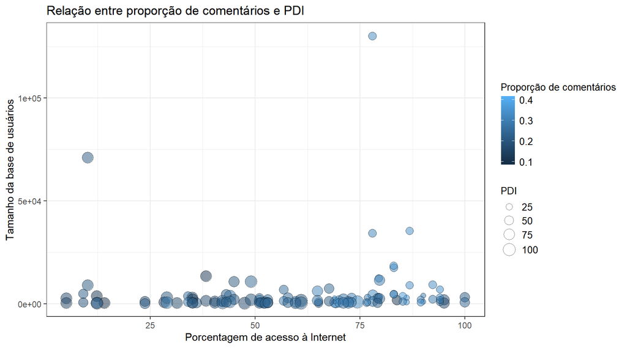

```r
dados %>%
  ggplot(aes(x = Internet, y = usuarios, fill = comentaram_prop, size = PDI)) +
  geom_point(alpha=0.5, shape=21) +
  labs(x = "Porcentagem de acesso à Internet", y = "Tamanho da base de usuários", fill = "Proporção de comentários", title = "Relação entre proporção de comentários e PDI") +
  theme(legend.position = "right", legend.direction = "vertical", legend.text = element_text(size = 10), legend.key.size = unit(0.5,"cm"), legend.title = element_text(size = 10))
```

O mesmo tipo de gráfico da questão anterior pode ser usado, entretanto com os dados auxiliares nos eixos X e Y, e os dados primários como legendas no gráfico (cor e tamanho). Essa visualização não é recomendável pois, por mais que mostre os mesmos dados, não foca na relação entre as variáveis primárias, isto é `comentaram_prop` e `PDI`. Sendo assim, a visualização acima acaba se tornando uma escolha não muito útil para a análise que queremos fazer.

3. Scatterplot com histograma marginal

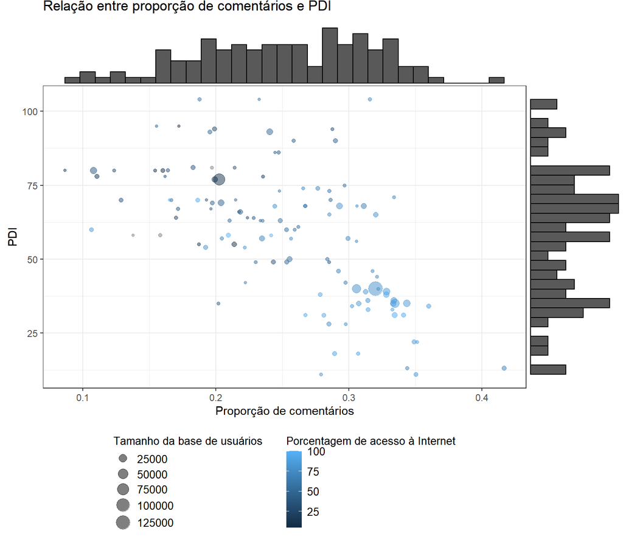

```r
grafico <- ggplot(dados, aes(x=comentaram_prop, y=PDI, color=Internet, size=usuarios)) +
      geom_point(alpha=0.5) +
      labs(x = "Proporção de comentários", y = "PDI", size = "Tamanho da base de usuários", colour = "Porcentagem de acesso à Internet", title = "Relação entre proporção de comentários e PDI") +
    theme(legend.position = "bottom", legend.direction = "vertical", legend.text = element_text(size = 10), legend.key.size = unit(0.5,"cm"), legend.title = element_text(size = 10))

ggMarginal(grafico, type="histogram")
```

Apesar de parecer um pouco com o gráfico da primeira questão, o histograma marginal que é acrescido ao gráfico não acrescenta muita coisa e acaba criando uma poluição visual desnecessária para realizar a análise que precisamos.

4. Histograma de densidade 2D

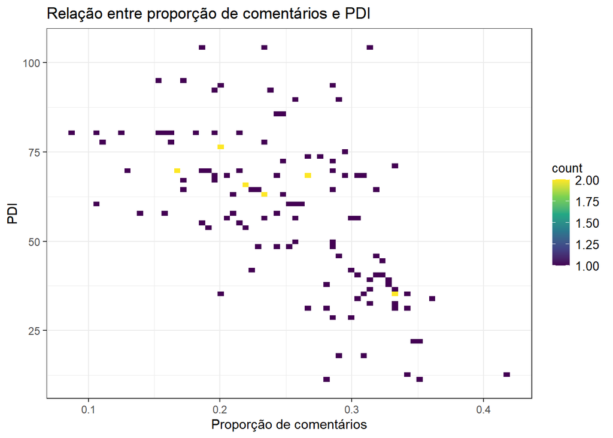

```r
dados %>%
  ggplot(aes(x=comentaram_prop, y=PDI, colour = Internet, size = usuarios)) +
  geom_bin2d(bins = 70) +
  scale_fill_continuous(type = "viridis") +
  theme_bw() +
  labs(x = "Proporção de comentários", y = "PDI", title = "Relação entre proporção de comentários e PDI") +
  theme(legend.position = "right", legend.direction = "vertical", legend.text = element_text(size = 10), legend.key.size = unit(0.5,"cm"), legend.title = element_text(size = 10))
```

5. Scatterplot conectado

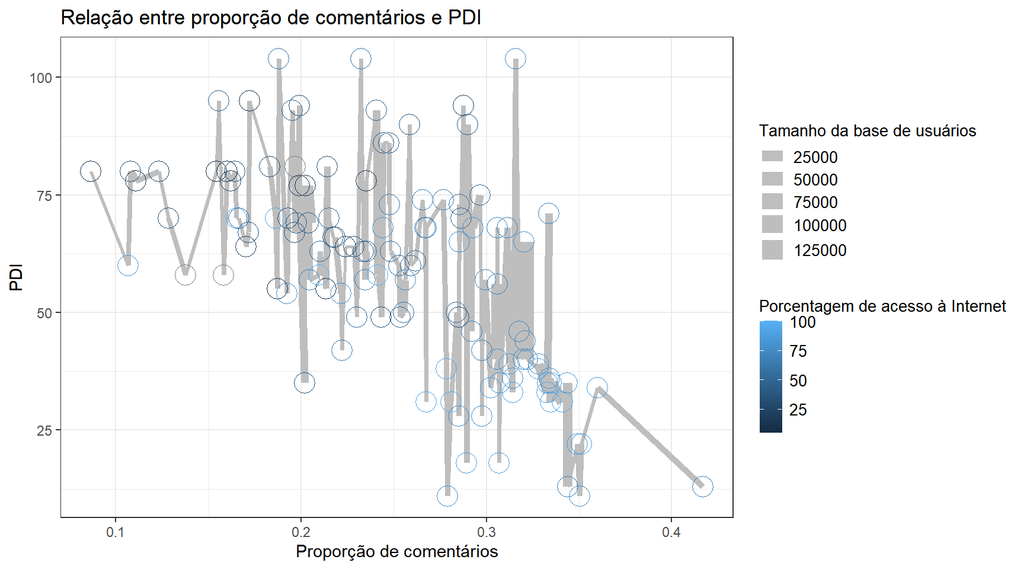

```r
dados %>%
  tail(121) %>%
  ggplot(aes(comentaram_prop, y=PDI, colour = Internet, size = usuarios)) +
    geom_line(color="grey") +
    geom_point(shape=21, size=6) +
    labs(x = "Proporção de comentários", y = "PDI", size = "Tamanho da base de usuários", colour = "Porcentagem de acesso à Internet", title = "Relação entre proporção de comentários e PDI") +
    theme(legend.position = "right", legend.direction = "vertical", legend.text = element_text(size = 10), legend.key.size = unit(0.5,"cm"), legend.title = element_text(size = 10))
```

Percebam que neste gráfico, adicionamos ao tail o número de observações que possuem os dados, sendo assim o gráfico estará correto do ponto de vista de corretude. Entretanto, o mesmo se torna muito poluído e confuso, de forma que não podemos observar praticamente nada que seja útil.

## Bônus

### Inclua o continente dos países (`six_regions`) na visualização.

Usaremos como base a primeira visualização que fizemos, isto é, a mais eficaz, que seria o scatterplot inicial.

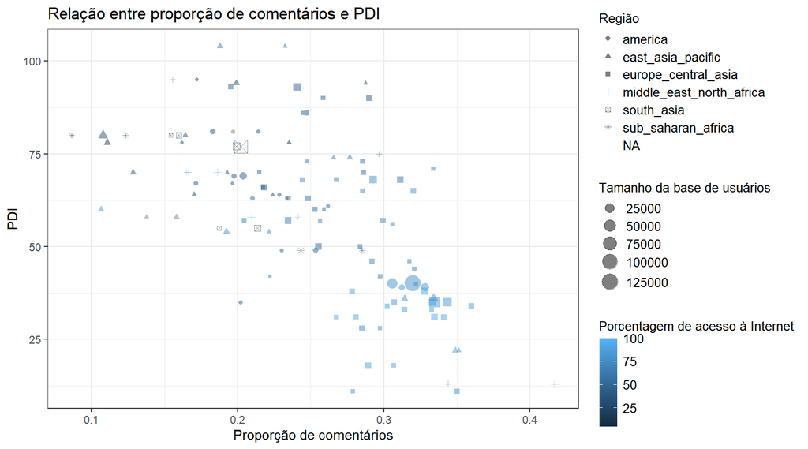

```r
dados %>%
  ggplot(aes(x = comentaram_prop, y = PDI, colour = Internet, size = usuarios, shape = six_regions)) +
  geom_point(alpha=0.5) +
  labs(x = "Proporção de comentários", y = "PDI", size = "Tamanho da base de usuários", colour = "Porcentagem de acesso à Internet", shape = "Região", title = "Relação entre proporção de comentários e PDI") +
  theme(legend.position = "right", legend.direction = "vertical", legend.text = element_text(size = 10), legend.key.size = unit(0.5,"cm"), legend.title = element_text(size = 10))
```

Como a variável `six_regions` é categórica, isto é, descreve regiões, diferentemente de `usuarios` e `Internet` que eram contínuas, usamos o shape do gráfico para representar as regiões possíveis, tornando a visualização mais intuitiva.